# Reserving Triangles - Lunch and Learn

[figure not shown]

# Introduction

## Contents

# What is Reserving, why is it important?

A claims reserve is a reserve of money that is set aside by an insurance company in order to pay policyholders who have filed or are expected to file legitimate claims on their policies. The claims reserve is also known as the balance sheet reserve. *(investopedia)*

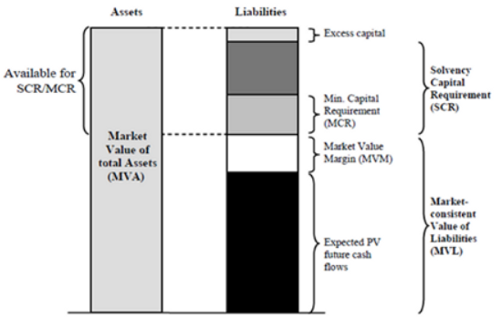

This feeds into the Best Estimate Liabilities calculation (Note: SCR it’s the European regulation, in the US they have something different)

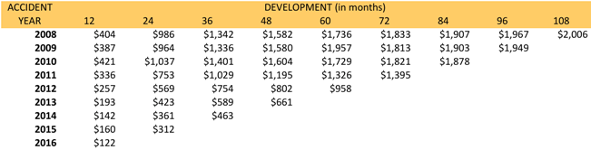

# Reserving methods

1. Chain Ladder Method
2. Bornhuetter/Ferguson Method
3. Mack ChainLadder
4. Munich ChainLadder
5. Bootstrap ChainLadder
6. Multivariate ChainLadder
7. Clark’s LDF method

**Let’s get to the coding**

# Create Triangles

Setup Code and Load Data

## Setting up our environment

First we load all our packages that we need.

```r
# Setup and Load Packages -------------------------------------------------
options(scipen = 999)
if (!is.element("yaml",     .packages(all.available = TRUE))) install.packages("yaml")
if (!is.element("devtools", .packages(all.available = TRUE))) install.packages("devtools")

for (func in list.files(path = "1_code/0_functions/", full.names = TRUE)) source(func)

# Load Meta data
metaData <- yaml::read_yaml(file = "metadata.yaml")

devtools::install_github(repo = metaData$connectionDetails$github$repo, auth_token = metaData$connectionDetails$github$token)
eaR::utl_pkgInstaller(libs = c("tidyverse", "lubridate"), destinationFolder = "C:/Users/a009831/Documents/rlibraries")
```

## Loading and prepping the data

I use a made up dataset in my example but there are example triangles in the chainladder package. I prepare my data with Quarterly information but you can change this depending on your needs.

```r
# Insurance Claims data ----------------------------------------------------
dat <- readr::read_csv("0_data/demoData.csv")
head(dat) %>% kablePretty()
```

| claimDate | paidDate | paidAmount |
| --- | --- | --- |
| 02/03/2020 | 18/03/2020 | 1718.3278 |
| 02/03/2020 | 18/03/2020 | 3062.4553 |
| 02/03/2020 | 06/04/2020 | 39746.5105 |
| 02/03/2020 | 28/04/2020 | 897.5728 |
| 23/02/2020 | 02/04/2020 | 7798.7193 |
| 10/01/2017 | 08/03/2017 | 1816.6294 |

```r
# Prep the data for your triangle by creating quarterly information to view development periods at a more granular level
dat <- dat %>%
  mutate(claimDate = lubridate::dmy(claimDate),
         paidDate = lubridate::dmy(paidDate),
         claimQ = lubridate::quarter(claimDate, with_year = TRUE),
         paidQ = lubridate::quarter(paidDate, with_year = TRUE))

head(dat) %>% kablePretty()
```

| claimDate | paidDate | paidAmount | claimQ | paidQ |
| --- | --- | --- | --- | --- |
| 2020-03-02 | 2020-03-18 | 1718.3278 | 2020.1 | 2020.1 |
| 2020-03-02 | 2020-03-18 | 3062.4553 | 2020.1 | 2020.1 |
| 2020-03-02 | 2020-04-06 | 39746.5105 | 2020.1 | 2020.2 |
| 2020-03-02 | 2020-04-28 | 897.5728 | 2020.1 | 2020.2 |
| 2020-02-23 | 2020-04-02 | 7798.7193 | 2020.1 | 2020.2 |
| 2017-01-10 | 2017-03-08 | 1816.6294 | 2017.1 | 2017.1 |

## Preprep functions for Triangles

First function creates the cumulative triangle using the three columns of input data

```r
# function to create the cumulative triangle
# Must have claimDate, paidDate, paidAmount

cumtriangleFunc <- function(data) {
  # prep the dates and calculating the development period
  prep <- data %>%
    dplyr::mutate(claimQY = lubridate::quarter(claimDate, with_year = TRUE),
                  claimQ = lubridate::quarter(claimDate),
                  claimYear = lubridate::year(claimDate),
                  paymentQ = lubridate::quarter(paidDate),
                  yearDiff = lubridate::year(paidDate) - lubridate::year(claimDate),
                  quarterDiff = paymentQ - claimQ,
                  devPeriod = ((yearDiff * 4) + quarterDiff)) %>%
    dplyr::group_by(claimYear, claimQY, devPeriod) %>%
    dplyr::summarise(paidAmount = sum(paidAmount))
  # Create a Mapping table for the claim years
  year <- sort(unique(prep$claimYear), decreasing = FALSE)
  yearmapping <- seq(0,length(unique(prep$claimYear)) - 1, by = 1)
  yearMultiplier <-  cbind.data.frame(year, yearmapping)

  prep <- prep %>%
    dplyr::group_by(claimQY, devPeriod) %>%
    dplyr::summarise(paidAmount = sum(paidAmount, na.rm = TRUE))

  minDt <- data$claimDate %>% min()
  maxDt <- data$claimDate %>% max()

  quarterRef <- tibble(dates = seq(minDt, maxDt, by = "month"),
                       claimQY = lubridate::quarter(dates, with_year = TRUE)) %>%
    select(claimQY) %>%
    distinct() %>%
    mutate(qtr = row_number())

  tri <- tibble(claimQY = quarterRef$claimQY %>% rep(nrow(quarterRef))) %>%
    arrange(claimQY) %>%
    mutate(devPeriod = seq(0, nrow(quarterRef) - 1, 1) %>% rep(nrow(quarterRef))) %>%
    left_join(prep) %>%
    mutate(paidAmount = ifelse(is.na(paidAmount), 0, paidAmount)) %>%
    dplyr::ungroup() %>%
    dplyr::group_by(claimQY) %>%
    left_join(quarterRef) %>%
    ChainLadder::as.triangle(origin = "claimQY", dev = "devPeriod", value = "paidAmount")

  # Flip triangle from left to right to get lower left triangle to be NA
  tri <- pracma::fliplr(tri)
  # Make the lower left triangle NA
  tri[lower.tri(tri)] <- NA
  # Flip triangle back to the right way
  tri <- pracma::fliplr(tri)

  #cum tri
  cumTri <- ChainLadder::incr2cum(Triangle = tri)
  return(cumTri)
}
```

Next function fills out the lower triangle using the weighted averages to predict the rest of the development periods

```r
# function to create the age to age factors and create the classic chainladder
# Give the function your cumulative triangle post fixes to nonfull months
fillLowTriFunc <- function(cumTri) {

  # Calculate Age to Age factors - Triangle
  ageToAge <- ChainLadder::ata(Triangle = cumTri)
  ageToAge[is.infinite(ageToAge)] <- 0

  # Volume weighted averages
  vwtd <- attr(ChainLadder::ata(cumTri), "vwtd")

  # For loop to fill in the lower triangle
  for (jj in 2:ncol(cumTri)) {
    cumTri[, jj][is.na(cumTri[, jj])] <- cumTri[, jj - 1][is.na(cumTri[, jj])] * vwtd[jj - 1]
  }

  # Sum of the diagonal
  latest <- cumTri %>%  pracma::fliplr() %>% diag() %>% sum()

  # Sum of the full years
  ultimate <- cumTri[,ncol(cumTri)] %>% sum()

  # Calculate the IBNR
  IBNR <- ultimate - latest

  return(cumTri)
}
```

Final function prints some statistics that might be useful

```r
# function to return the stats about chainladder
# Give the function your final triangle
triStatsFunc <- function(finTri) {

# Sum of the diagonal
latest <- finTri %>%  pracma::fliplr() %>% diag() %>% sum()

# Sum of the full years
ultimate <- finTri[,ncol(finTri)] %>% sum()

# Calculate the IBNR
IBNR <- ultimate - latest

results <- list(paste0("Latest = ", latest), paste0("Ultimate = ", ultimate), paste0("IBNR = ", IBNR))
return(results)

}
```

## Triangles

```r
# Create my cumulative triangle
cumTri <- cumtriangleFunc(dat)
cumTri
```

```
        devPeriod
claimQY           0        1        2        3        4        5        6
  2017.1 5771239.48 14379331 16240282 17148261 17634621 17772180 17845807
  2017.2 5195482.45 12180971 13912630 14440262 14831669 14942670 15032961
  2017.3 7243369.92 15009312 16975285 17802756 18190519 18385546 18536768
  2017.4 5265428.97 12443895 14026758 14732100 15054496 15253540 15372598
  2018.1 5561987.68 16012616 18293033 19191393 19628985 19800592 19844752
        devPeriod
claimQY         7        8        9       10       11       12       13
  2017.1 17980177 18072020 18117603 18124328 18133002 18140154 18140154
  2017.2 15131881 15234956 15245525 15245525 15262568 15262568       NA
  2017.3 18589155 18662452 18667025 18671389 18671389       NA       NA
  2017.4 15405636 15437551 15437551 15437551       NA       NA       NA
  2018.1 19922135 20042547 20051699       NA       NA       NA       NA
 [ reached getOption("max.print") -- omitted 9 rows ]
```

```r
# Mack Chainladder method using ChainLadder package
mackTri <- ChainLadder::MackChainLadder(Triangle = cumTri)
mackTri
```

```
ChainLadder::MackChainLadder(Triangle = cumTri)

           Latest Dev.To.Date   Ultimate      IBNR Mack.S.E CV(IBNR)
2017.1 18,140,154       1.000 18,140,154         0        0      NaN
2017.2 15,262,568       1.000 15,262,568         0    2,302      Inf
2017.3 18,671,389       1.000 18,675,388     3,999    6,684    1.672
2017.4 15,437,551       0.999 15,448,488    10,937   11,816    1.080
2018.1 20,051,699       0.999 20,069,202    17,504   14,490    0.828
2018.2 16,503,448       0.998 16,531,053    27,605   22,722    0.823
2018.3 19,594,247       0.994 19,706,745   112,498   56,490    0.502
2018.4 14,526,568       0.991 14,662,414   135,846   64,409    0.474
2019.1 20,201,161       0.986 20,478,246   277,084   95,268    0.344
2019.2 16,296,628       0.979 16,647,770   351,142  103,873    0.296
2019.3 20,312,112       0.958 21,192,248   880,136  174,783    0.199
2019.4 14,082,730       0.922 15,277,134 1,194,404  263,670    0.221
 [ reached 'max' / getOption("max.print") -- omitted 2 rows ]

                  Totals
Latest:   221,198,448.73
Dev:                0.97
Ultimate: 226,992,470.05
IBNR:       5,794,021.32
Mack.S.E      774,128.26
CV(IBNR):           0.13
```

```r
# Fill in lower triangle
Tri <- fillLowTriFunc(cumTri)
Tri
```

```
        devPeriod
claimQY           0           1          2           3          4           5
  2017.1 5771239.48 14379331.02 16240282.1 17148260.63 17634620.6 17772180.39
  2017.2 5195482.45 12180971.24 13912630.3 14440261.69 14831668.8 14942669.66
  2017.3 7243369.92 15009312.02 16975284.6 17802756.11 18190519.3 18385545.79
  2017.4 5265428.97 12443894.62 14026758.0 14732100.40 15054495.6 15253539.99
  2018.1 5561987.68 16012615.69 18293032.9 19191393.45 19628984.8 19800591.89
        devPeriod
claimQY            6           7           8           9          10
  2017.1 17845806.87 17980177.37 18072020.23 18117603.39 18124327.91
  2017.2 15032961.07 15131880.91 15234956.17 15245524.68 15245524.68
  2017.3 18536767.52 18589154.69 18662451.96 18667024.99 18671389.39
  2017.4 15372598.03 15405636.03 15437551.25 15437551.25 15437551.25
  2018.1 19844751.96 19922135.18 20042547.05 20051698.61 20054994.29
        devPeriod
claimQY           11          12          13
  2017.1 18133001.56 18140154.11 18140154.11
  2017.2 15262567.76 15262567.76 15262567.76
  2017.3 18671389.39 18675388.37 18675388.37
  2017.4 15445179.88 15448487.88 15448487.88
  2018.1 20064904.68 20069202.11 20069202.11
 [ reached getOption("max.print") -- omitted 9 rows ]
```

```r
# Calculate Age to Age factors - Triangle
ageToAge <- ChainLadder::ata(Triangle = cumTri)
ageToAge[is.infinite(ageToAge)] <- 0
ageToAge
```

```
        devPeriod
claimQY    0-1   1-2   2-3   3-4   4-5   5-6   6-7   7-8   8-9 9-10 10-11 11-12
  2017.1 2.492 1.129 1.056 1.028 1.008 1.004 1.008 1.005 1.003    1 1.000     1
  2017.2 2.345 1.142 1.038 1.027 1.007 1.006 1.007 1.007 1.001    1 1.001     1
  2017.3 2.072 1.131 1.049 1.022 1.011 1.008 1.003 1.004 1.000    1 1.000    NA
  2017.4 2.363 1.127 1.050 1.022 1.013 1.008 1.002 1.002 1.000    1    NA    NA
  2018.1 2.879 1.142 1.049 1.023 1.009 1.002 1.004 1.006 1.000   NA    NA    NA
        devPeriod
claimQY  12-13
  2017.1     1
  2017.2    NA
  2017.3    NA
  2017.4    NA
  2018.1    NA
 [ reached getOption("max.print") -- omitted 10 rows ]
```

```r
# write.csv(x = ageToAge, file = "ageToAge.csv")

# Volume weighted averages
vwtd <- attr(ChainLadder::ata(cumTri), "vwtd")
vwtd
```

```
     0-1      1-2      2-3      3-4      4-5      5-6      6-7      7-8
2.159298 1.129898 1.039760 1.021324 1.007725 1.004324 1.003590 1.004062
     8-9     9-10    10-11    11-12    12-13
1.000799 1.000164 1.000494 1.000214 1.000000
```

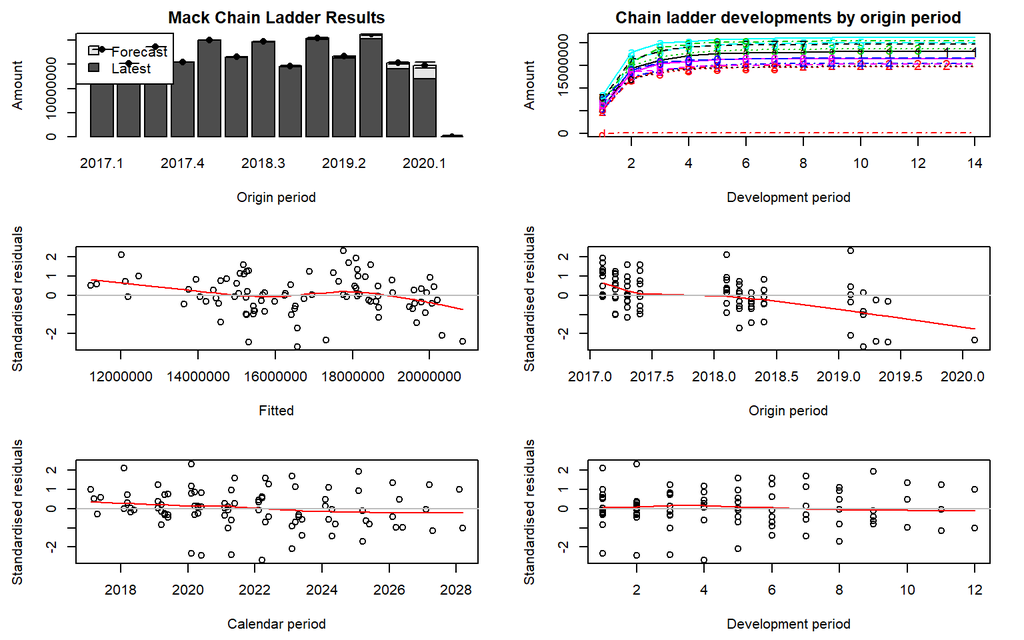

```r
# write.csv(x = vwtd, file = "vwtd.csv")

# smpl <- attr(ChainLadder::ata(cumTri), "smpl")
# write.csv(x = smpl, file = "smpl.csv")

# plot
plot(mackTri, legend = FALSE)
```

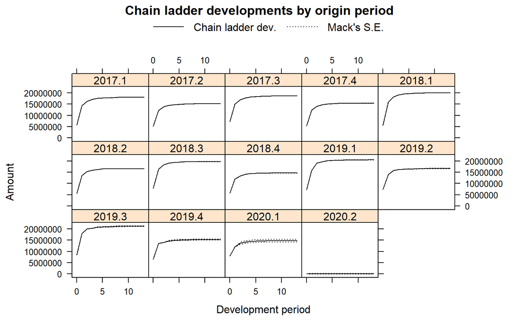

```r
plot(mackTri, lattice = TRUE)
```

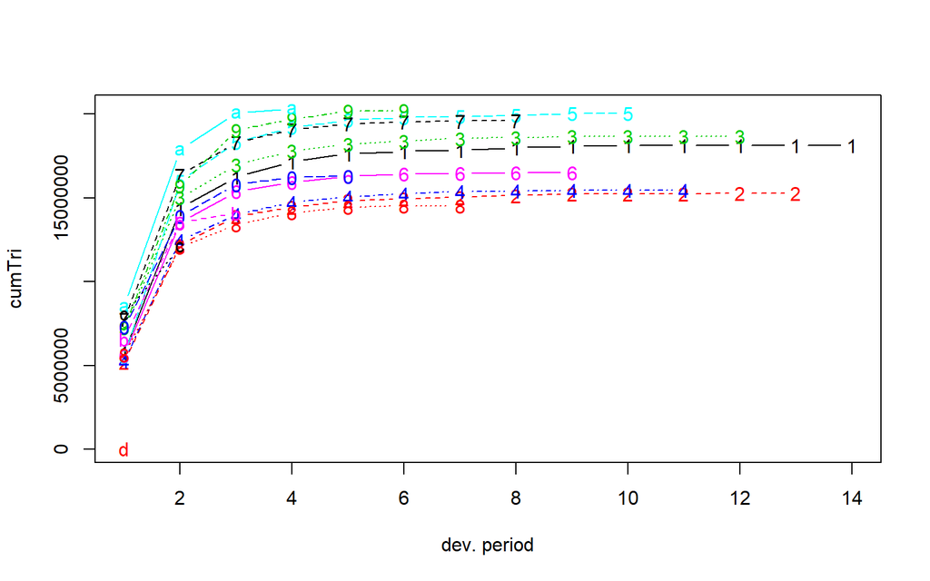

```r
plot(cumTri)
```

```r
# Get stats on Triangle
TriStats <- triStatsFunc(Tri)
TriStats
```

```
[[1]]
[1] "Latest = 221198448.72691"

[[2]]
[1] "Ultimate = 226992470.046833"

[[3]]
[1] "IBNR = 5794021.31992337"
```

```r
# Export cumTriangle, it's best to export this as a csv to keep the shape of the triangle in Excel
# write.csv(x = cumTri, file = "2_results/cumTri.csv")

# Export finTriangle
# write.csv(x = Tri, file = "2_results/Tri.csv")

# Export stats on Triangle
# write.csv(x = TriStats, file = "2_results/TriStats.csv")
```

# Other info

### Creating triangles in Python

https://github.com/CodeCerebro/Loss_Triangle https://actuarialdata.net/Loss_Development_Triangle_in_Python/

### Importing Triangles from Excel into R

https://magesblog.com/post/2014-11-18-first-steps-with-chainladder-import/ https://katrienantonio.github.io/Risk-modelling-in-insurance/claims-reserving.html

### Example data for Triangles

https://github.com/mages/diesunddas/blob/master/ChainLadder/RAA.csv

### Information about Triangles

https://theactuarialclub.com/2019/05/16/introduction-of-run-off-triangles-in-reserving/#Technical_Aspect https://www.captive.com/news/2017/02/20/basics-of-loss-development-triangles https://www.r-bloggers.com/2012/01/statistical-methods-for-the-chain-ladder-technique-revisited/